# Exploratory Data Analysis Final Project

Matthew Mucker

Sunday, May 3, 2015

For the final project, I really wanted to use data avaialble to me from my job. However, the few datasets that initially looked promising were all in relational format, and the effort to denormalize the data into a single flat table was going to be significant.

So I went with the white wine data set.

# Initial Exploration

The first thing I did, of course, was to load the data set into R studio. I looked at the names of the columns and summary data for each column:

```
##  [1] "X"                    "fixed.acidity"        "volatile.acidity"
##  [4] "citric.acid"          "residual.sugar"       "chlorides"
##  [7] "free.sulfur.dioxide"  "total.sulfur.dioxide" "density"
## [10] "pH"                   "sulphates"            "alcohol"
## [13] "quality"
```

```
##        X        fixed.acidity    volatile.acidity  citric.acid
##  Min.   :   1   Min.   : 3.800   Min.   :0.0800   Min.   :0.0000
##  1st Qu.:1225   1st Qu.: 6.300   1st Qu.:0.2100   1st Qu.:0.2700
##  Median :2450   Median : 6.800   Median :0.2600   Median :0.3200
##  Mean   :2450   Mean   : 6.855   Mean   :0.2782   Mean   :0.3342
##  3rd Qu.:3674   3rd Qu.: 7.300   3rd Qu.:0.3200   3rd Qu.:0.3900
##  Max.   :4898   Max.   :14.200   Max.   :1.1000   Max.   :1.6600
##  residual.sugar     chlorides       free.sulfur.dioxide
##  Min.   : 0.600   Min.   :0.00900   Min.   :  2.00
##  1st Qu.: 1.700   1st Qu.:0.03600   1st Qu.: 23.00
##  Median : 5.200   Median :0.04300   Median : 34.00
##  Mean   : 6.391   Mean   :0.04577   Mean   : 35.31
##  3rd Qu.: 9.900   3rd Qu.:0.05000   3rd Qu.: 46.00
##  Max.   :65.800   Max.   :0.34600   Max.   :289.00
##  total.sulfur.dioxide    density             pH          sulphates
##  Min.   :  9.0        Min.   :0.9871   Min.   :2.720   Min.   :0.2200
##  1st Qu.:108.0        1st Qu.:0.9917   1st Qu.:3.090   1st Qu.:0.4100
##  Median :134.0        Median :0.9937   Median :3.180   Median :0.4700
##  Mean   :138.4        Mean   :0.9940   Mean   :3.188   Mean   :0.4898
##  3rd Qu.:167.0        3rd Qu.:0.9961   3rd Qu.:3.280   3rd Qu.:0.5500
##  Max.   :440.0        Max.   :1.0390   Max.   :3.820   Max.   :1.0800
##     alcohol         quality
##  Min.   : 8.00   Min.   :3.000
##  1st Qu.: 9.50   1st Qu.:5.000
##  Median :10.40   Median :6.000
##  Mean   :10.51   Mean   :5.878
##  3rd Qu.:11.40   3rd Qu.:6.000
##  Max.   :14.20   Max.   :9.000
```

From this, it appears that ‘X’ is simply a unique identifier for the wine. The other 12 variables appear to be continuous measurements of the chemical properties of each wine variety. Quick observations can be made from the summary output. The mean and median of fixed acidity show that most wines are acidic (below a pH of 7.0). At least one wine is extrarodinarily basic, with a pH of 14.2. In fact, my knowledge of chemistry is that pH has a maximum value of 14, so this measurement is either erroneous, or isn’t a true pH value, or my understanding is wrong. (Perhaps)

Volatile acidity and Citric Acid measurements also have mean and median values well below the maximum value. So I expect to see at least one outlier in each of these measurements. It will be interesting to see if the same wine is responsible for the outlier in each of these attributes.

It turns out that this is where it’s helpful to read the documentation. According to the text file that accompanies the data set, these three columns are not pH values, but are rather measurements of tartaric acid, acetic acid, and citric acid in grams per cubic decimeter. My college background is in laboratory medicine, so this unit seems odd to me. Google Calculator tells me that one gram per cubic decimeter is the same as one milligram per milliliter, which helps give me some context.

Therefore, my observations above should be reinterpreted to mean that at least one wine has an exceedingly high acid content in each of these three categories. It reamins to bee seen if the same wine is responsible for the outlier for all measurements, or if different wines are responsible for the outlier(s) in each case.

Most of the variables have similar outliers. The exceptions seem to be density (which makes sense; wine should have a density close to that of water), and pH, which appears to be in a relatively narrow range. However, pH is a logarithmic scale so my initial interpretation might need to be examined more closely.

Quality, the output variable, is not well documented. I’m going to assume that this is a subjective score of the wine, hopefully one generated by a judge or judges that are trained in wine tasting. Given the range of values, I’m guessing wines were scored on a scale of 1 to 10 (or 0 to 10). The difference between the 1st and 3rd quartiles is very small; most wines are going to have a score of 5 or 6. That does make that maximum value more interesting: if most wines score a 5 or 6, I want to taste that wine that scored a 9!

It appears that there are no categorical variables in the dataset. Let’s check:

```r
str(pf)
```

```
## 'data.frame':    4898 obs. of  13 variables:
##  $ X                   : int  1 2 3 4 5 6 7 8 9 10 ...
##  $ fixed.acidity       : num  7 6.3 8.1 7.2 7.2 8.1 6.2 7 6.3 8.1 ...
##  $ volatile.acidity    : num  0.27 0.3 0.28 0.23 0.23 0.28 0.32 0.27 0.3 0.22 ...
##  $ citric.acid         : num  0.36 0.34 0.4 0.32 0.32 0.4 0.16 0.36 0.34 0.43 ...
##  $ residual.sugar      : num  20.7 1.6 6.9 8.5 8.5 6.9 7 20.7 1.6 1.5 ...
##  $ chlorides           : num  0.045 0.049 0.05 0.058 0.058 0.05 0.045 0.045 0.049 0.044 ...
##  $ free.sulfur.dioxide : num  45 14 30 47 47 30 30 45 14 28 ...
##  $ total.sulfur.dioxide: num  170 132 97 186 186 97 136 170 132 129 ...
##  $ density             : num  1.001 0.994 0.995 0.996 0.996 ...
##  $ pH                  : num  3 3.3 3.26 3.19 3.19 3.26 3.18 3 3.3 3.22 ...
##  $ sulphates           : num  0.45 0.49 0.44 0.4 0.4 0.44 0.47 0.45 0.49 0.45 ...
##  $ alcohol             : num  8.8 9.5 10.1 9.9 9.9 10.1 9.6 8.8 9.5 11 ...
##  $ quality             : int  6 6 6 6 6 6 6 6 6 6 ...
```

We see that all of the input data is continuous data, and the output is an integer. That makes sense to me given the documentation on the dataset. (I suppose an integer is actually an ordered categorical variable.)

# Initial Exploration - Single Variable

There are eleven input variables. While I could do the same single-variable analysis on each of these eleven inputs, I don’t think that’s likely to be a productive application of the course material. When I look at the variables, I note that there are several measurements related to acidity: fixed acidity, volatile acidity, citric acid, and pH all jump out as similar measures. Later, I’ll probably want to explore relationships between these variables. But for now, I’m going to look a little more at each of these variables in isolation. I plotted histograms of each of these variables:

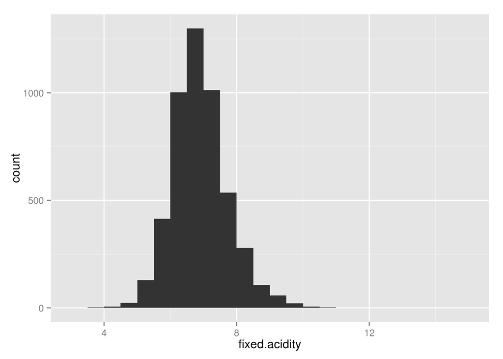

```r
qplot(x = fixed.acidity, data = pf, binwidth = 0.5)
```

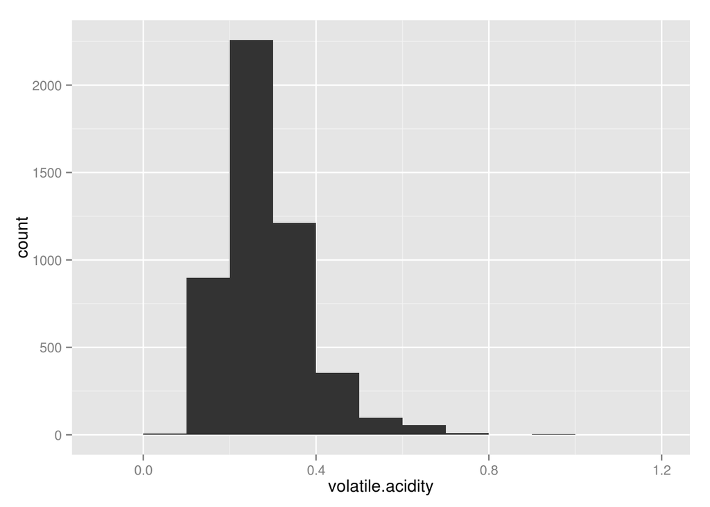

```r
qplot(x = volatile.acidity, data = pf, binwidth = 0.1)
```

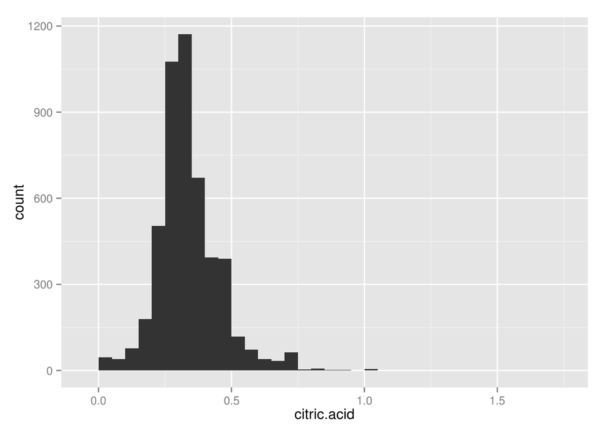

```r
qplot(x = citric.acid, data = pf, binwidth = 0.05)
```

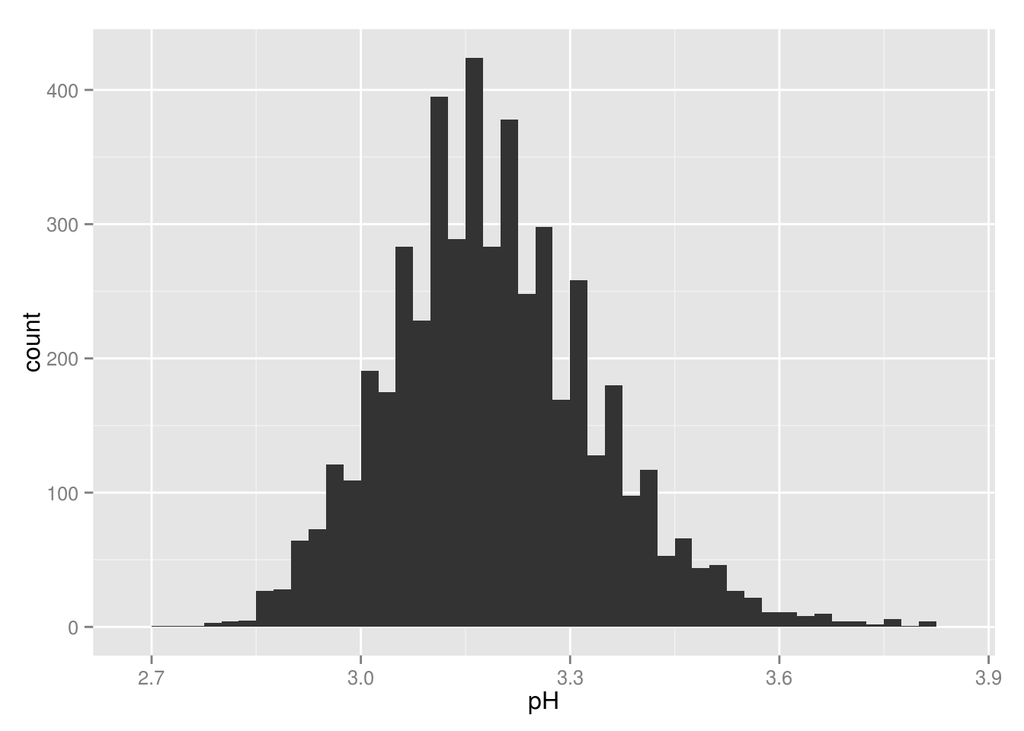

```r
qplot(x = pH, data = pf, binwidth = 0.025)
```

As the summary suggested, we see outliers on the top end of fixed acidity, volatile acidity, and citric acid. Even pH appears to have outliers at the upper end of the curve. However, an outlier at the upper end of the pH scale means a value is LESS acidic, where the other graphs get MORE acidic as we move to the right of the graph. In any case, it will be interesting to see later if the same wine(s) are responsible for the outliers on all the graphs, or if different wines are responsible for the individual variable outliers.

Without knowing how this data was measured and collected, it’s impossible to know if the outliers are valid data or if they were inaccurate measurements. With no evidence to the contrary, I think that we have to treat all data as valid.

I see that fixed acidity appears to be a more-or-less Normal distribution. Volatile acidity has a longer tail to the right than it does to the left, but still has a unimodal distribution. Citric acid has a few outliers that are WAY down the graph but is similar to the distribution of volatile acidity. Lastly, pH looks like a Normal distribution, but with an odd stair-stepping pattern. I suspect this is an artifact of the resolution of the equipment used to take the measurements; it’s hard to believe that such a pattern would occur naturally in such a large sample of wines. I found this plot as I was playing with bindwidths and included it as an example of what a ‘wrong’ application of visualization might look like.

# Two-Variable Analysis

The first two-varaible relationship that I wanted to explore is the relationship between each of the acidity measurements and pH. I think I’m likely to find some interesting relationships there. I don’t understand the relationships that these individual measures have, but I do know that pH is a well understood measurement of the acidity of a liquid. I wanted to know if any of the individual acidity measurements are strongly correlated with pH. To do this, I created scatter plots of fixed acidity, volatile acidity, and citric acid and plotted them against pH:

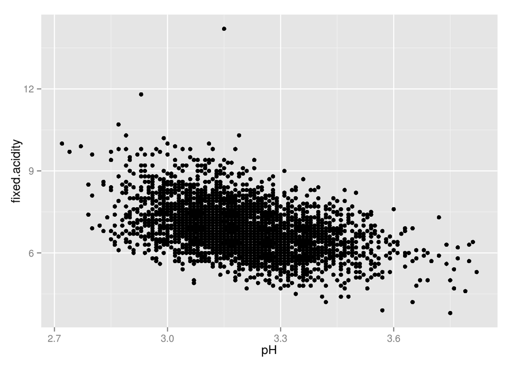

```r
ggplot(aes(x=pH, y=fixed.acidity), data=pf) + geom_point()
```

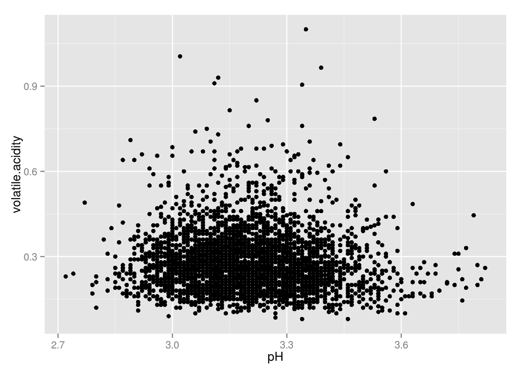

```r
ggplot(aes(x=pH, y=volatile.acidity), data=pf) + geom_point()
```

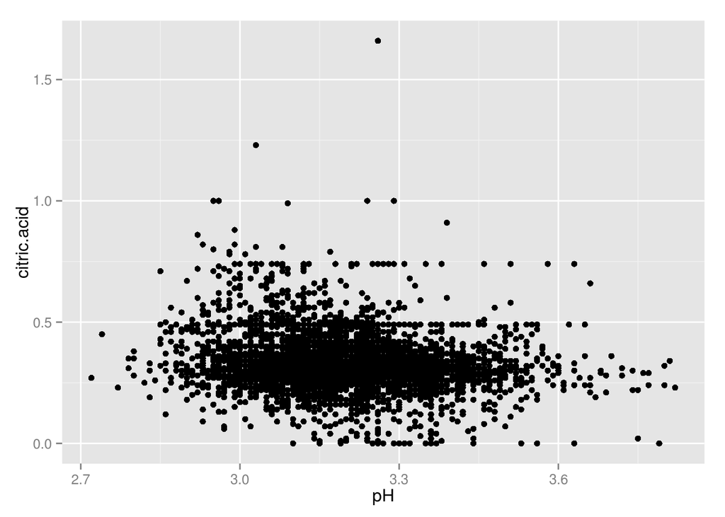

```r
ggplot(aes(x=pH, y=citric.acid), data=pf) + geom_point()
```

I don’t see a striking relationship between any of these variables and pH as I had hoped. However, there are two observations to be made. The first is that fixed acidity does appear to have a negative, possibly linear, correlation with pH. There’s a pretty wide distribution from the best fit line, but I think an argument can be made that this relationship probably exists by looking at the plot. (Adding a basic knowledge of chemistry to looking at the plot makes this argument stronger.) Neither volatile acidity nor citric acid appear to have an observable correlation with pH.

The second thing I notice in these plots is an odd horizontal line at citric acid = 0.75, and another at 0.5. There are enough wines with citric acid just above 0.75 and just below 0.75 that I don’t think this is likely to be a measurement error. If we were looking at a manufactured product, I’d suspect that perhaps there might be a legal or regulatory or market-driven force that would create a boundary like this. However, wines are the product of fermentation rather than direct manipulation of ingredients, so I don’t think that’s the case here. Without further data, I have no explanation for why there appears to be such a distinct cutoff for this measurement.

I decided to overlay the best fit line on the fixed acidity vs. pH plot, as a refresher for myself and to prepare myself for creating more complicated plots:

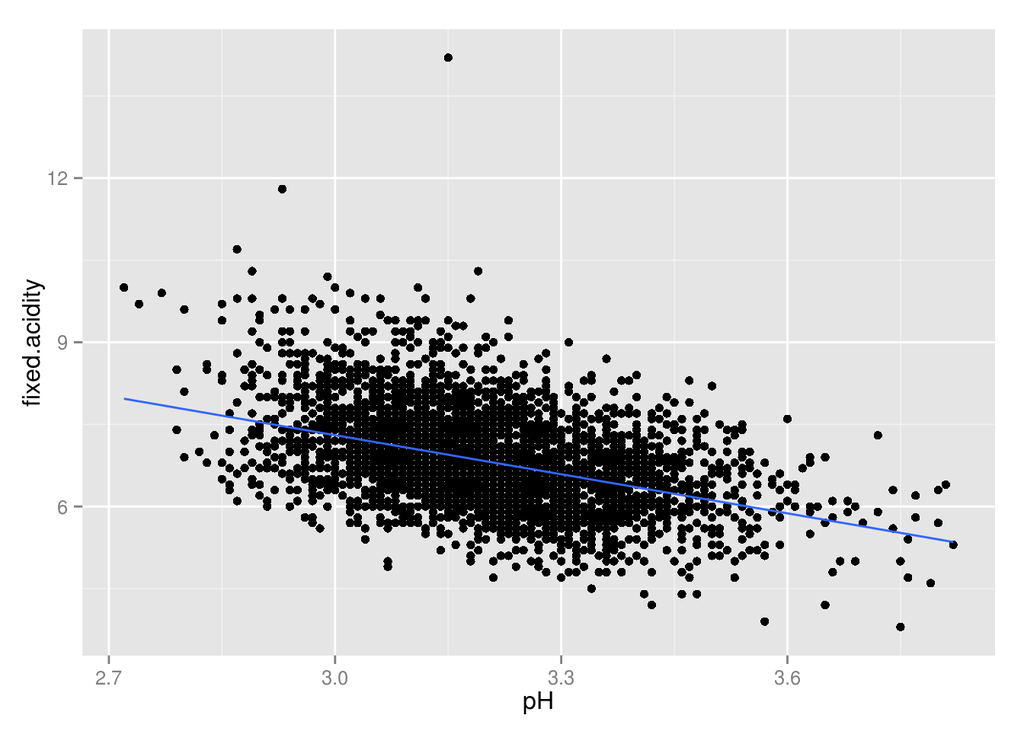

```r
ggplot(aes(x=pH, y=fixed.acidity), data=pf) + geom_point() + stat_smooth(method="lm", se=FALSE)
```

This plot doesn’t really tell me anything that I didn’t already discover in the previous plot, but it can help to call attention to the relationship between the two variables.

Because Quality is the ‘output variable’ in this data set, I wanted to see if any of the individual measurements had any correlation with quality. Examining eleven input variables would require eleven plots such as this one:

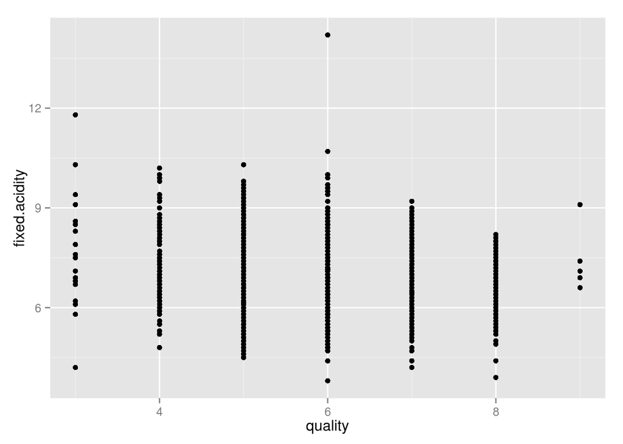

```r
ggplot (aes(x=quality, y = fixed.acidity), data=pf) + geom_point()
```

This plot is not easy to read. Because the output variable is a categorical variable, there is no continuity in the graph. A jitter in the X axis can help with this visualization. Transparency can help avoid overplotting at the same time:

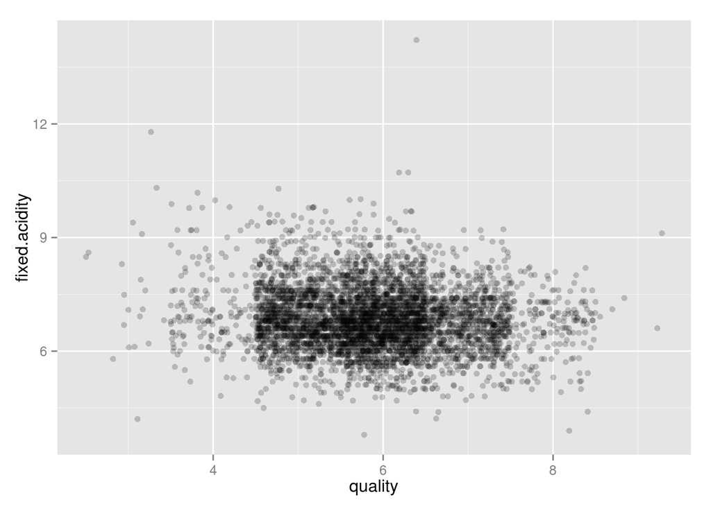

```r
ggplot (aes(x=quality, y = fixed.acidity), data=pf) + geom_point(alpha = .2, position = position_jitter(width = 0.5))
```

While this plot is easier to read, it does risk giving the viewer a false sense that the X variable is a continuous variable.

Now that I have a strategy for plotting each of the eleven input varaibles against the output variable, I chose to plot each of the input varables against the output variable separately. Ideally, if I find a few variables that strongly correlate with the output variable, I’d like to find a way to present those in a single plot. But for my initial exploration I do want to look at each variable separately:

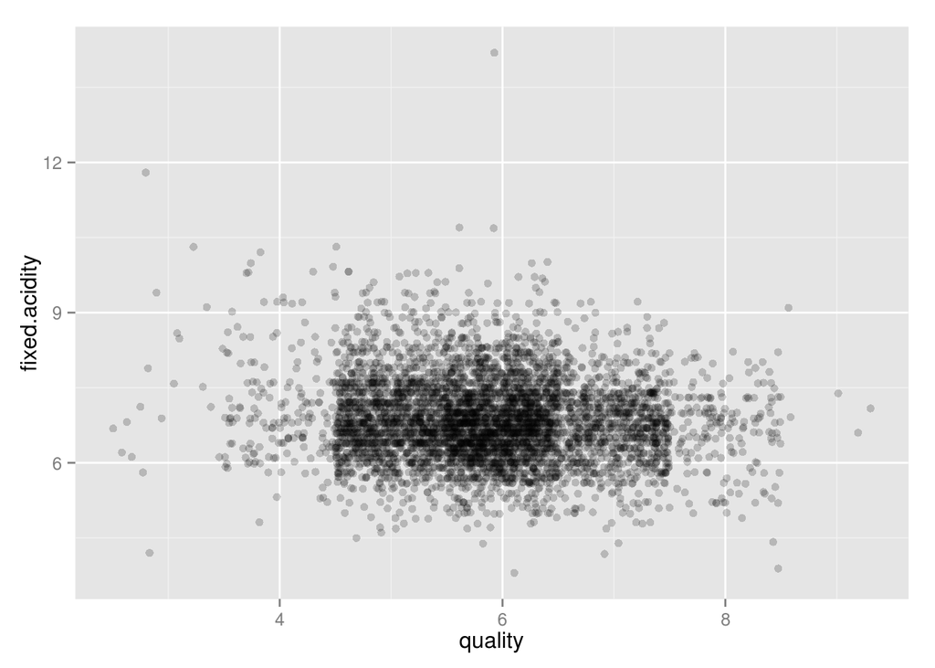

```r
ggplot (aes(x=quality, y = fixed.acidity), data=pf) + geom_point(alpha = .2, position = position_jitter(width = 0.5))
```

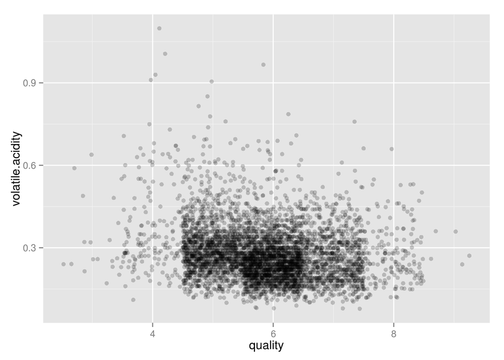

```r
ggplot (aes(x=quality, y = volatile.acidity), data=pf) + geom_point(alpha = .2, position = position_jitter(width = 0.5))
```

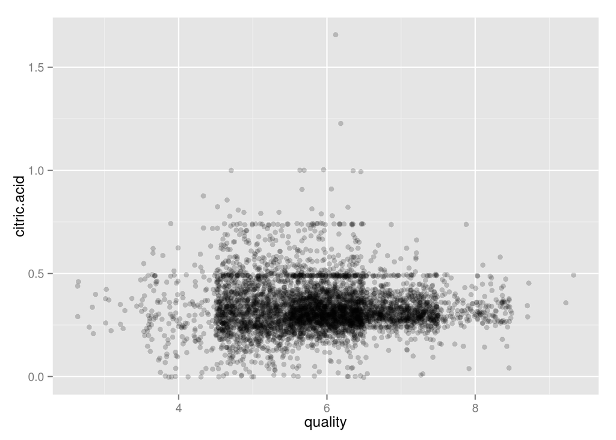

```r
ggplot (aes(x=quality, y = citric.acid), data=pf) + geom_point(alpha = .2, position = position_jitter(width = 0.5))
```

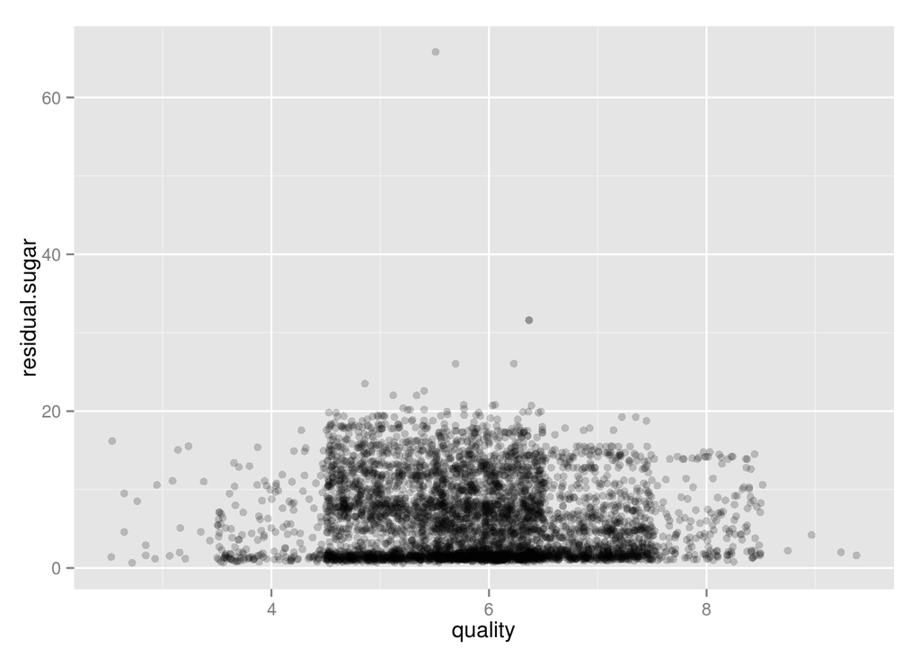

```r
ggplot (aes(x=quality, y = residual.sugar), data=pf) + geom_point(alpha = .2, position = position_jitter(width = 0.5))
```

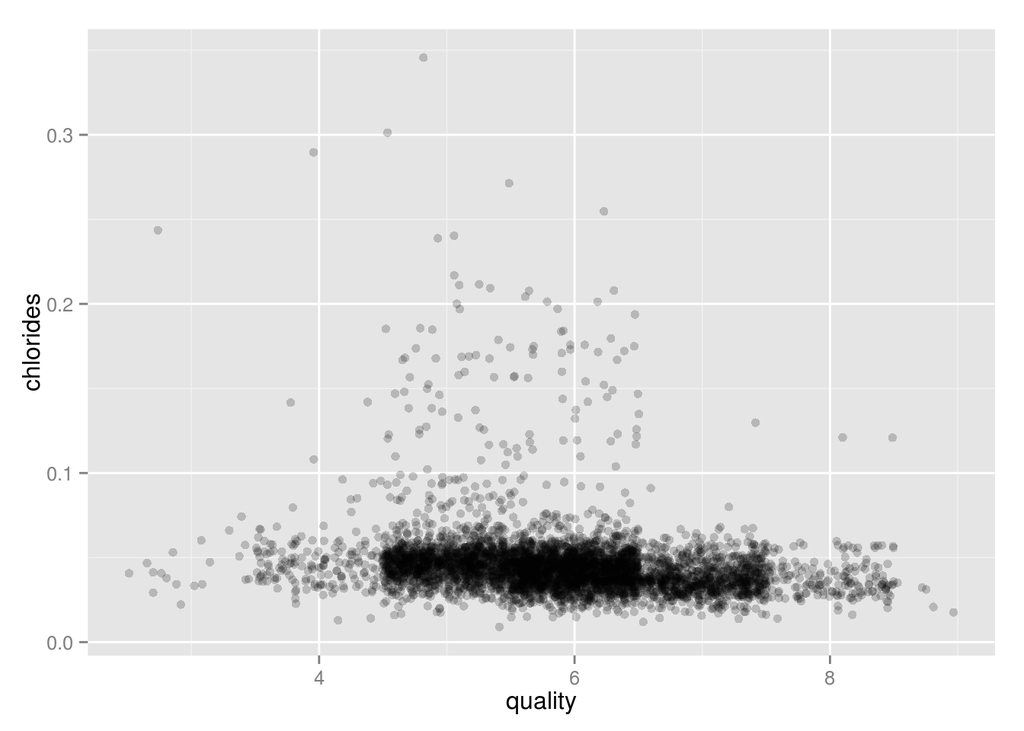

```r
ggplot (aes(x=quality, y = chlorides), data=pf) + geom_point(alpha = .2, position = position_jitter(width = 0.5))
```

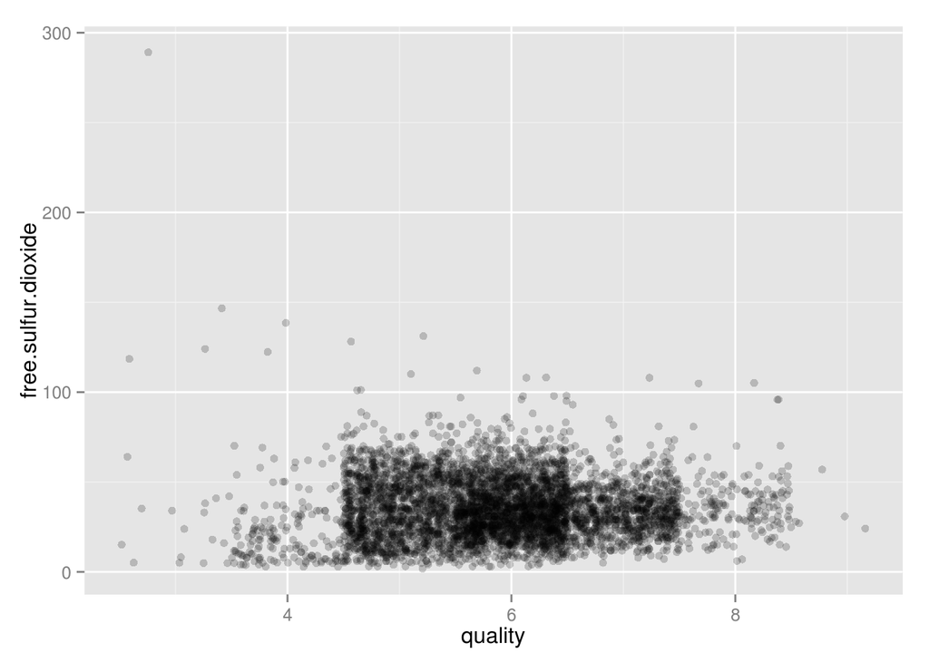

```r
ggplot (aes(x=quality, y = free.sulfur.dioxide), data=pf) + geom_point(alpha = .2, position = position_jitter(width = 0.5))
```

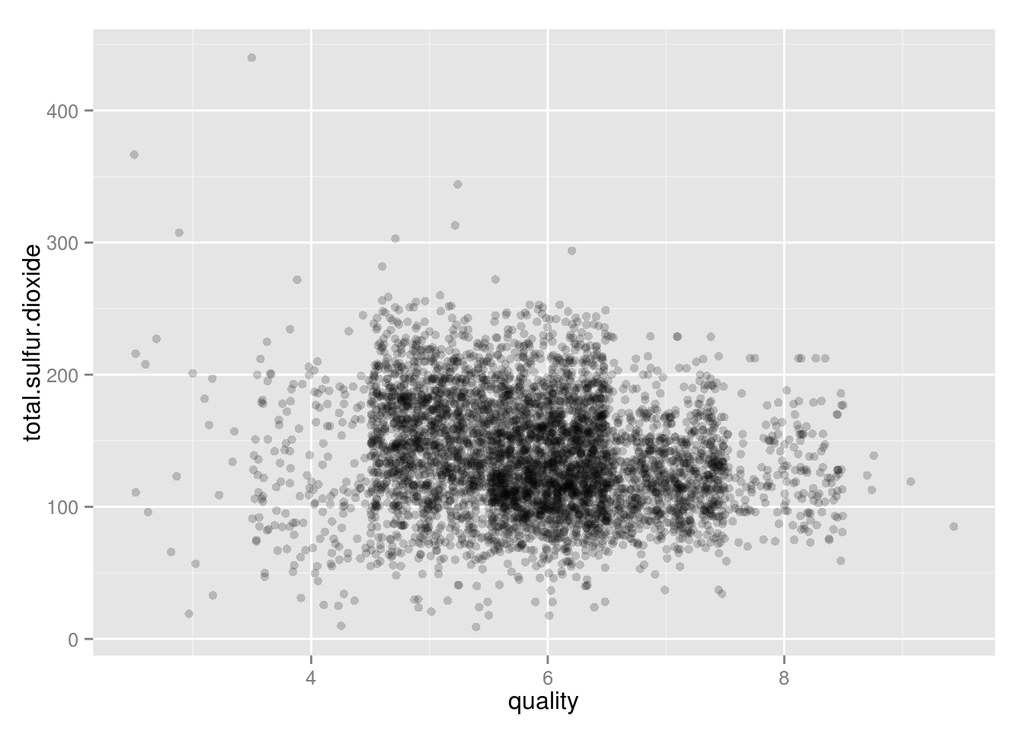

```r
ggplot (aes(x=quality, y = total.sulfur.dioxide), data=pf) + geom_point(alpha = .2, position = position_jitter(width = 0.5))
```

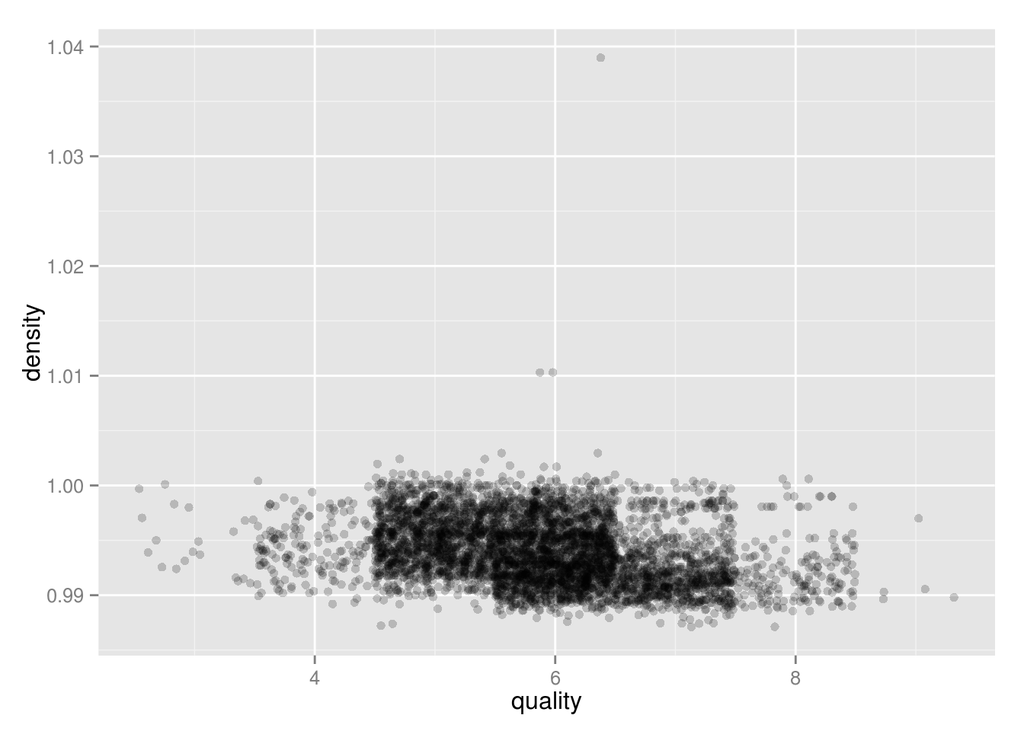

```r
ggplot (aes(x=quality, y = density), data=pf) + geom_point(alpha = .2, position = position_jitter(width = 0.5))
```

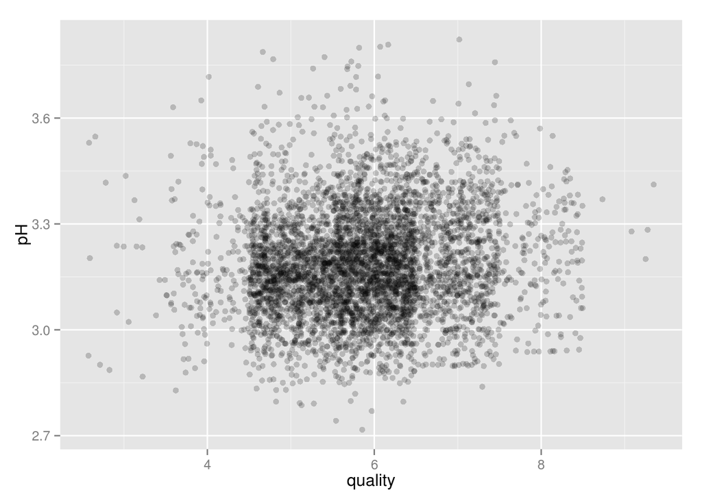

```r
ggplot (aes(x=quality, y = pH), data=pf) + geom_point(alpha = .2, position = position_jitter(width = 0.5))
```

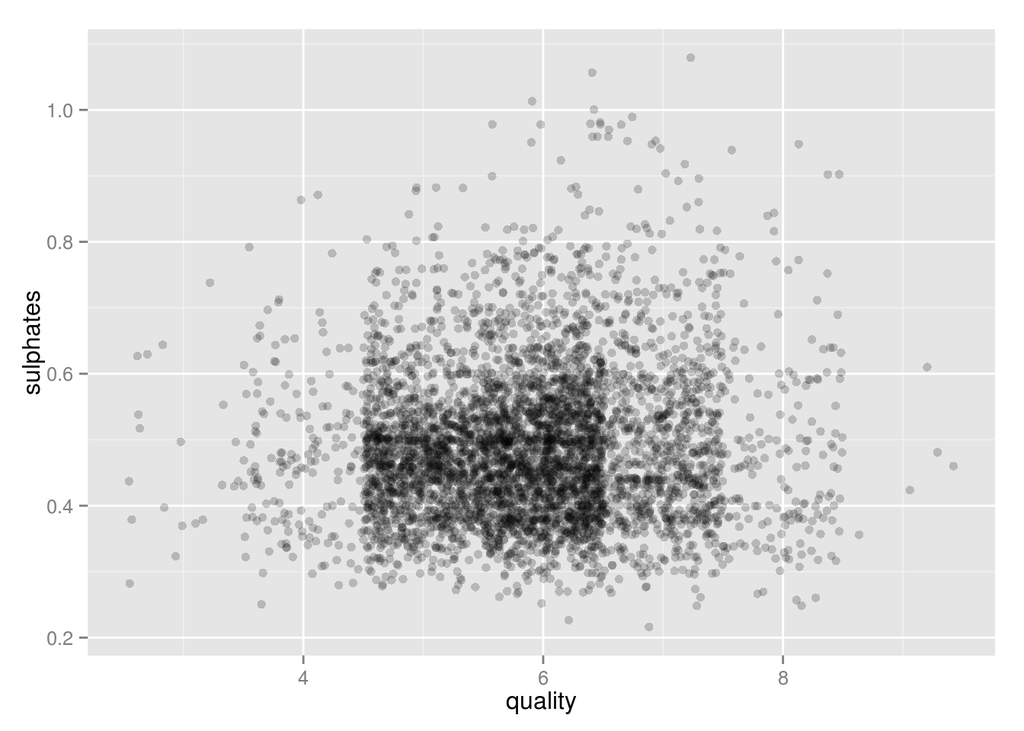

```r
ggplot (aes(x=quality, y = sulphates), data=pf) + geom_point(alpha = .2, position = position_jitter(width = 0.5))
```

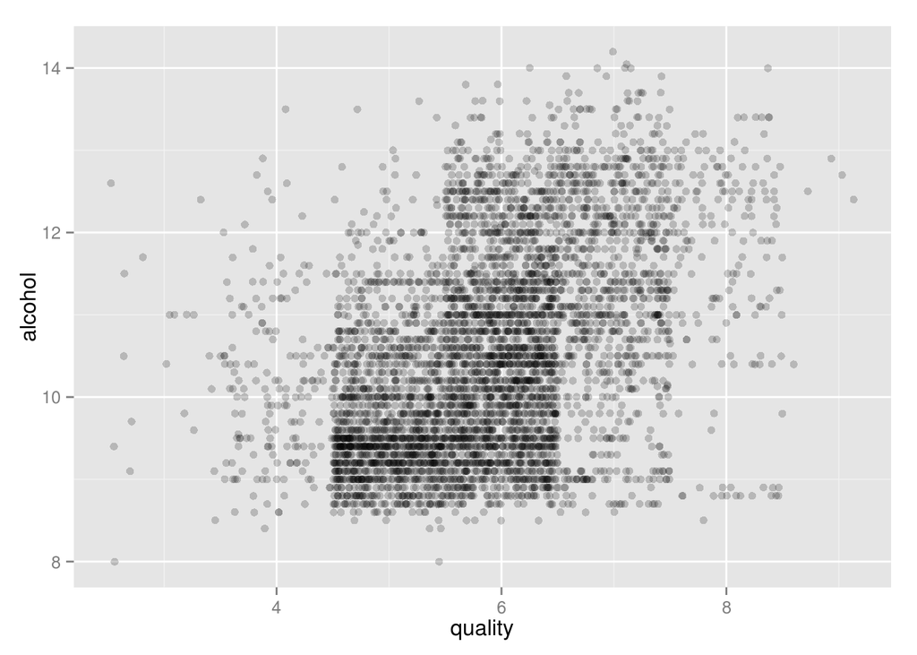

```r
ggplot (aes(x=quality, y = alcohol), data=pf) + geom_point(alpha = .2, position = position_jitter(width = 0.5))
```

Next, I wanted to see if there was any relationship between the three measurements of acidity. For each wine, I am thinking about plotting volatile acidity, fixed acidity, and citric acid on the same plot. The naive way to do this is to use the wine’s label as the X axis, and the three measurements as separate lines:

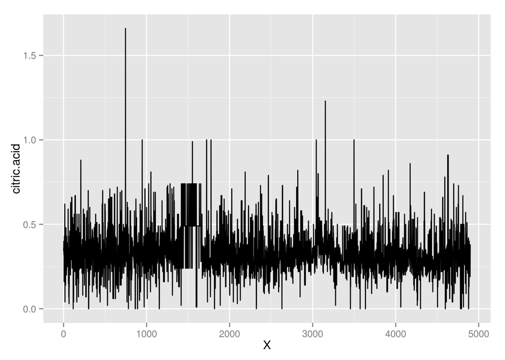

```r
ggplot(aes(x=X, y=citric.acid), data=pf) + geom_line()
```

This creates a mess. Since the X dimension is an arbitrary value, there’s no way to see trends or relationships. Instead, I chose one of the three measurements (citric acid) and plotted the other two measurements against that one:

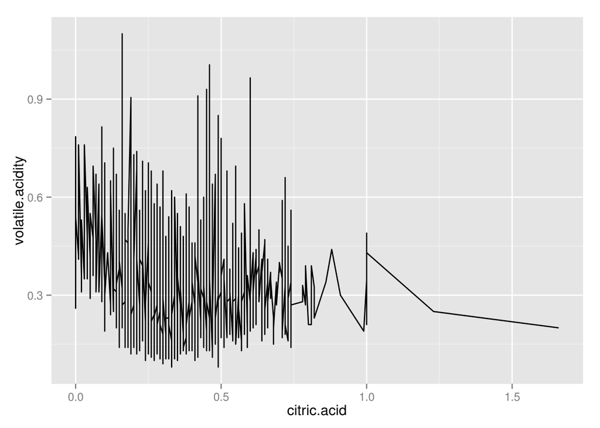

```r
ggplot(aes(x = citric.acid, y = volatile.acidity), data = pf) + geom_line()
```

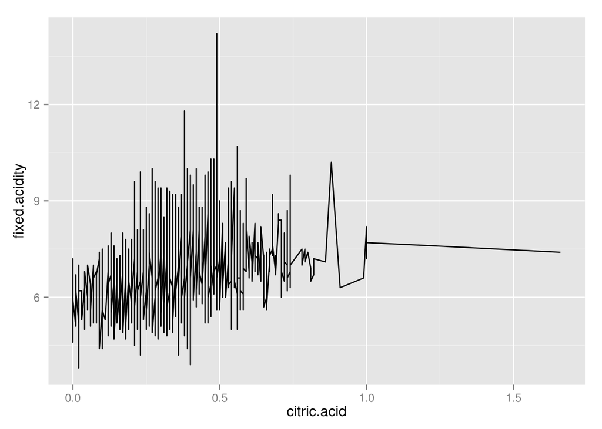

```r
ggplot(aes(x = citric.acid, y = fixed.acidity), data = pf) + geom_line()
```

I don’t see enough of a trend here that would warrant one plot with both of these curves on it. Let’s lastly look at the relationship between fixed and volatile acidity:

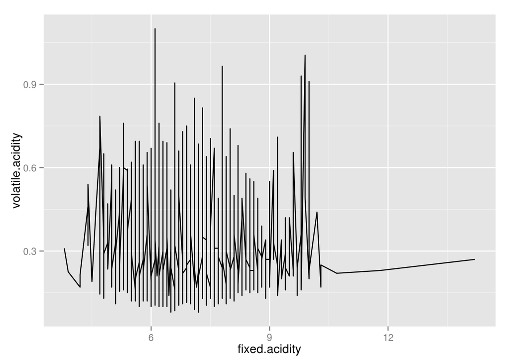

```r
ggplot(aes(x=fixed.acidity, y = volatile.acidity), data = pf) + geom_line()
```

I think these three plots do a good job demonstrating that there’s no relationship between the three measurements of acidity. I found that a little surprising, but it’s hard to argue with those graphs. Since I was thinking about acidity and plots, I wanted to do a frequency plot showing fixed acidity, volatile acidity, and citric acid vs. pH. This is actually three lines on the same plot rather than a true frequency plot:

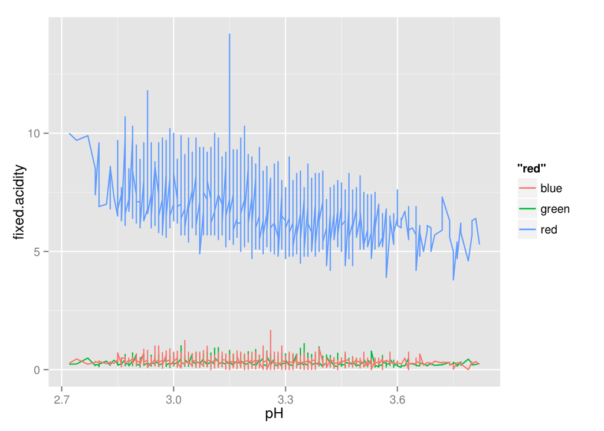

```r
ggplot (data = pf, aes(x = pH)) +
  geom_line(aes(y = fixed.acidity, color = "red")) +
  geom_line (aes(y = volatile.acidity, color = "green")) +
  geom_line(aes(y = citric.acid, color = "blue"))
```

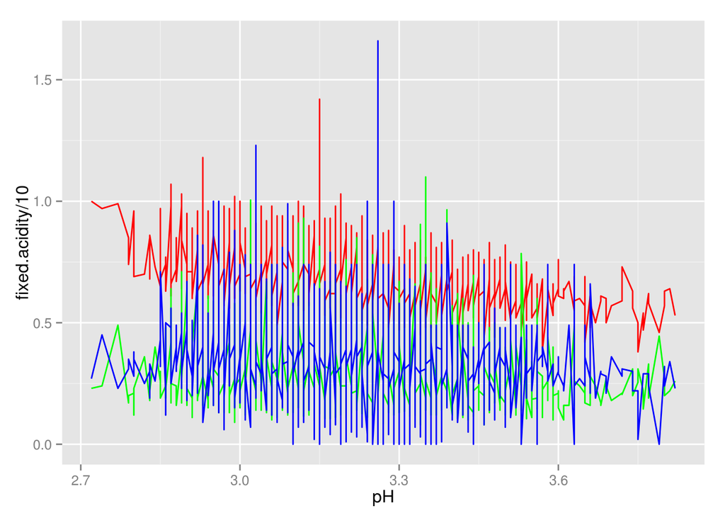

```r
ggplot (data = pf, aes(x = pH)) +
  geom_line(aes(y = fixed.acidity / 10), color = 'red') +
  geom_line (aes(y = volatile.acidity), color = 'green') +
  geom_line(aes(y = citric.acid), color = 'blue' )
```

This plot is a mess and probably isn’t very useful as it is displayed. However, I think the concept that I’m trying to illustrate here is appropriate for an exploratory data analysis; I just don’t know enough abour ggplot to coerce it into displaying what I’d like.

# Correlations

At this point I was a little discouraged that I didn’t find any relationships that appear worth further exploration. The next thing I wanted to do is look at all the correlations between the various attributes of the wines. I did this using the scatterplot matrix:

[figure not shown]

Unfortunately, there’s a lot of information crammed into a small space there, and it’s impossible to read this matrix. I was unable to find any documentation that would explain how to make this plot more readable. I was hoping that finding a high correlation coefficient or two would help me find additional relationships between variables that I could explore.

# Final Plots

The first plot I want to highlight is the plot of pH vs. fixed acidity. I took the plot I did initially and added some alpha transparency to help show the density of points. I added some color to the points, and labeled units on the Y axis and gave the plot a title.

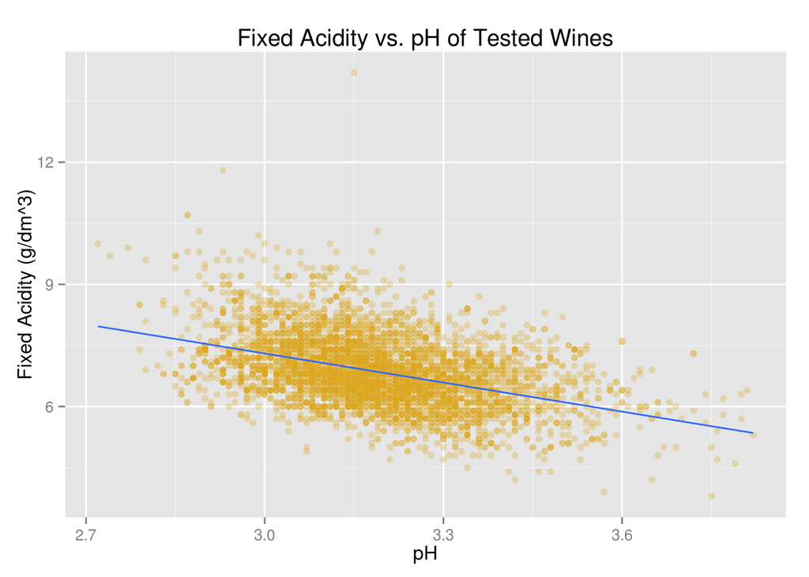

```r
ggplot(aes(x=pH, y=fixed.acidity), data=pf) + geom_point(alpha = 0.3, color='goldenrod') + stat_smooth(method="lm", se=FALSE) +
  ylab("Fixed Acidity (g/dm^3)") + ggtitle("Fixed Acidity vs. pH of Tested Wines")
```

Although a simple plot, this is an effective visual to demonstrate that there is a relationship between the fixed acidity of a wine and its pH.

At this point, I’m stuck. I can’t fine 2 plots in the work that I’ve done so far that warrant further exhibition. I’m hoping the evaluators might be able to provide some feedback on the work that I’ve done, or suggest other areas to exploer, so that I can make a second attempt at the project.

# Reflection

This project was more involved than I thought it would be. The first thing that struck me about this project is that since the output variable ‘Quality’ is a categorical variable, it made it difficult to come up with good visualizations to show how each of the input variables affects the output variable.

I also found myself confused about some of the plot types. For example, the box plot is introduced in the single-variable lesson, but the box plot actually requires both an X and a Y variable, which I interpret to mean this is actually a two-variable plot.

The dearth of categorical variables in the data set made it difficult to use some of the techinques illustrated in the lectures. For instance, faceting requires a categorical variable over which to facet the data.